# Assignment

# Regression Problem

```r
library(ISLR2)
library(corrplot)
library(performance)
library(effects)
library(caret)
library(splines)
```

```r
reg_data <- Boston[, c(5, 7, 8, 12, 13)]
colnames(reg_data)
```

```
## [1] "nox"   "age"   "dis"   "lstat" "medv"
```

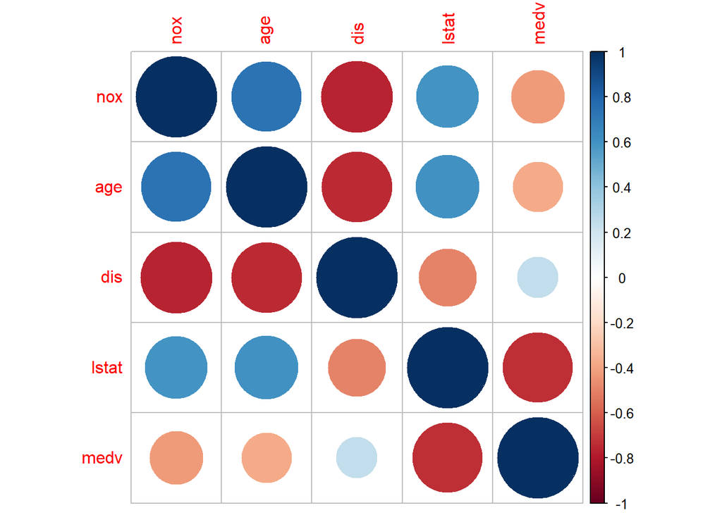

```r
cor <- cor(reg_data)
corrplot(cor)
```

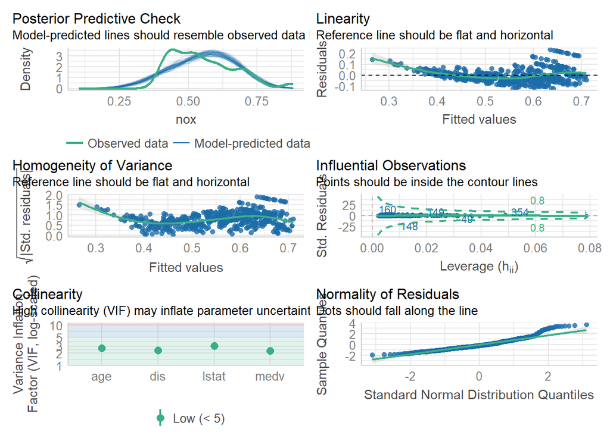

```r
lin_mod <- lm(nox ~ age + dis + lstat + medv, data = reg_data)
check_model(lin_mod)
```

It appears as though we have a non-linear fit.

## Age

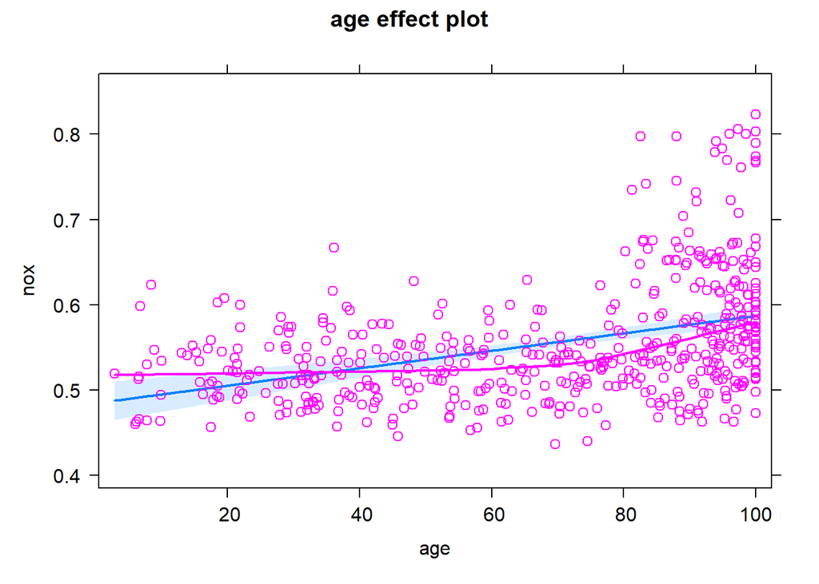

```r
plot(effect("age", mod = lin_mod, partial.residuals = TRUE))
```

```r
data("reg_data")
set.seed(42)

train_control <- trainControl(method = "LOOCV")
```

### Linear fit

```r
age_lin <- train(nox ~ age, data = reg_data, method = "lm", trControl = train_control)
age_lin_RMSE <- age_lin$results$RMSE
```

### Poly Fit

```r
poly_mse <- rep(0, 8)

for (i in 1:8) {
    data <- reg_data
    data$polyfit <- poly(data$age, i)
    poly_age <- train(nox ~ polyfit, data = data,
        method = "lm", trControl = train_control)
    poly_mse[i] <- poly_age$results$RMSE
}

age_poly_RMSE <- min(poly_mse)

which.min(poly_mse)
```

```
## [1] 2
```

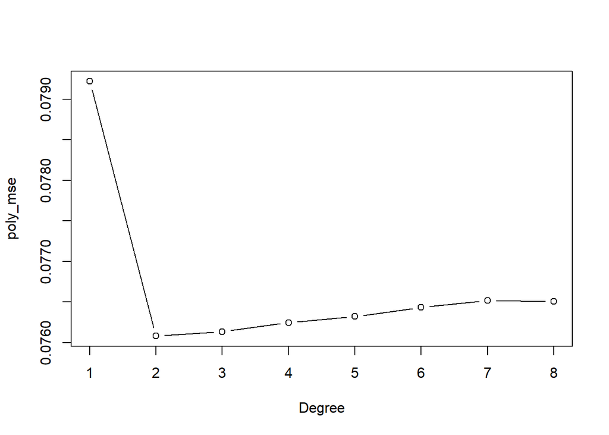

```r
plot(1:8, poly_mse, type = "b", xlab = "Degree")
```

We can see here that a quadratic fit (2-degrees) results in the lowest RMSE. Let’s now have a look at other methods.

### Basis Splines Fit

```r
bs_mse <- rep(0, 20)

for (i in 1:20) {
    data <- reg_data
    data$bspline <- bs(reg_data$age, df = i)
    bs_age <- train(nox ~ bspline, data = data,
        method = "lm", trControl = train_control)
    bs_mse[i] <- bs_age$results$RMSE
}
```

[output not shown]

[output cut: 9052 more lines]

[output not shown]

```r
age_bs_RMSE <- min(bs_mse)

which.min(bs_mse)
```

```
## [1] 1
```

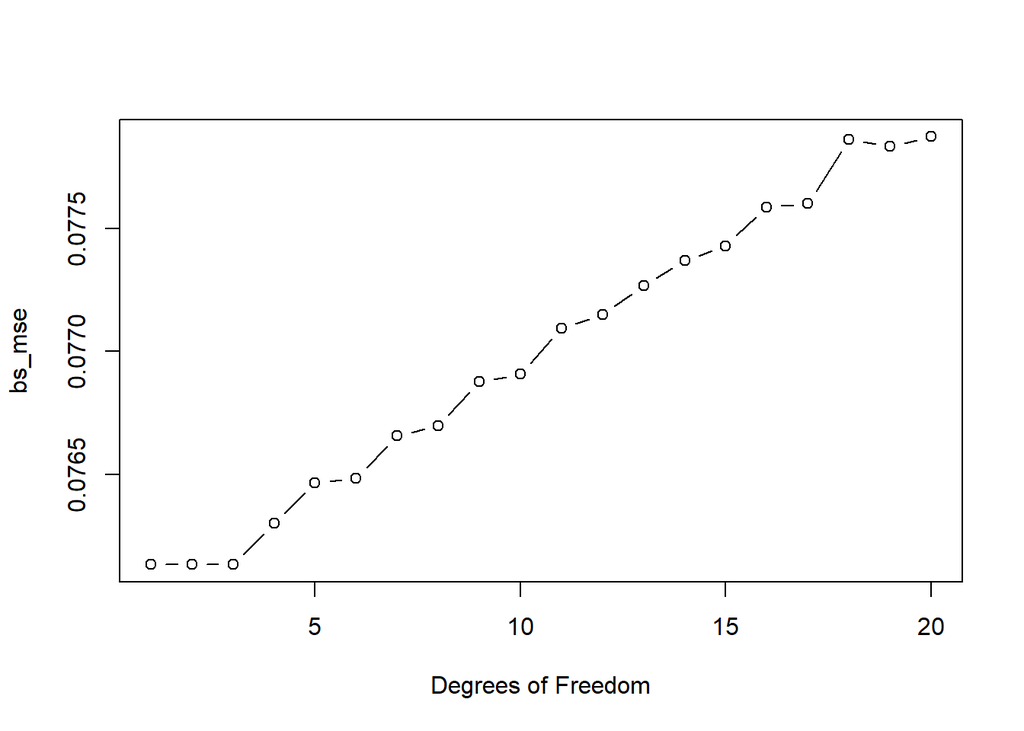

```r
plot(1:20, bs_mse, type = "b", xlab = "Degrees of Freedom")
```

### Natural Splines

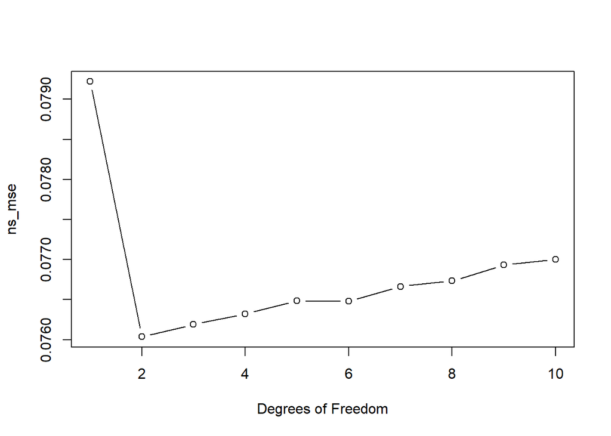

```r
ns_mse <- rep(0, 10)

for (i in 1:10) {
    data <- reg_data
    data$nspline <- ns(reg_data$age, df = i)
    age_ns <- train(nox ~ nspline, data = data,
        method = "lm", trControl = train_control)
    ns_mse[i] <- age_ns$results$RMSE
}

age_ns_RMSE <- min(ns_mse)

plot(1:10, ns_mse, type = "b", xlab = "Degrees of Freedom")
```

### Age Selection

```r
which.min(c(age_lin_RMSE, age_poly_RMSE, age_bs_RMSE, age_ns_RMSE))
```

```
## [1] 4
```

```r
age_lin_RMSE
```

```
## [1] 0.07922101
```

```r
min(poly_mse)
```

```
## [1] 0.07608232
```

```r
min(bs_mse)
```

```
## [1] 0.07613534
```

```r
min(ns_mse)
```

```
## [1] 0.07603695
```

```r
which.min(poly_mse)
```

```
## [1] 2
```

```r
which.min(bs_mse)
```

```
## [1] 1
```

```r
which.min(ns_mse)
```

```
## [1] 2
```

The natural splines results in the lowest RMSE. This results from just 2 degrees of freedom, so a parsamonious model.

## Dis

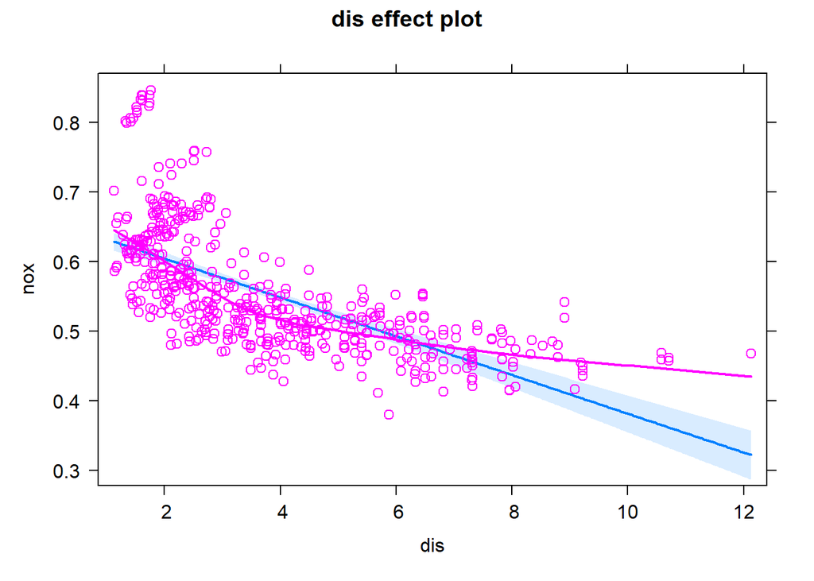

```r
plot(effect("dis", mod = lin_mod, partial.residuals = TRUE))
```

### Linear fit

```r
dis_lin <- train(nox ~ dis, data = reg_data, method = "lm", trControl = train_control)
dis_lin_RMSE <- dis_lin$results$RMSE
```

### Poly Fit

```r
poly_mse <- rep(0, 8)

for (i in 1:8) {
    data <- reg_data
    data$polyfit <- poly(data$dis, i)
    poly_dis <- train(nox ~ polyfit, data = data,
        method = "lm", trControl = train_control)
    poly_mse[i] <- poly_dis$results$RMSE
}

dis_poly_RMSE <- min(poly_mse)

which.min(poly_mse)
```

```
## [1] 3
```

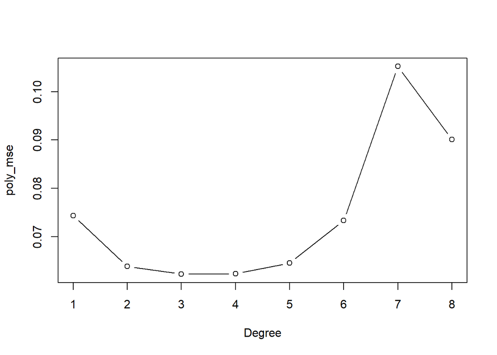

```r
plot(1:8, poly_mse, type = "b", xlab = "Degree")
```

### Basis Splines Fit

```r
bs_mse <- rep(0, 20)

for (i in 1:20) {
    data <- reg_data
    data$bspline <- bs(reg_data$dis, df = i)
    bs_dis <- train(nox ~ bspline, data = data,
        method = "lm", trControl = train_control)
    bs_mse[i] <- bs_dis$results$RMSE
}
dis_bs_RMSE <- min(bs_mse)

which.min(bs_mse)
```

```
## [1] 10
```

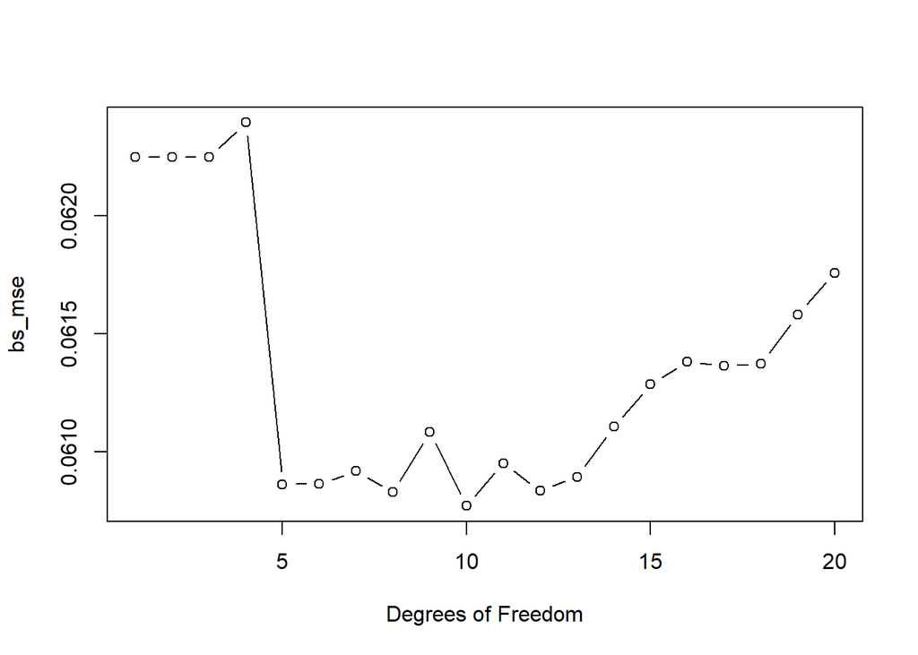

```r
plot(1:20, bs_mse, type = "b", xlab = "Degrees of Freedom")
```

### Natural Splines

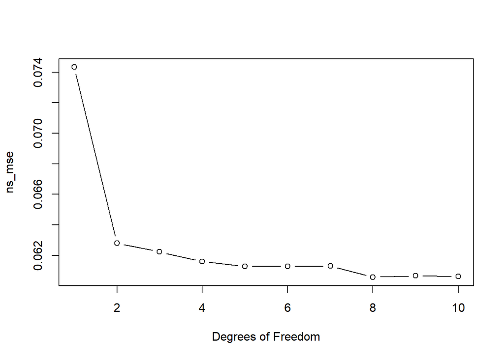

```r
ns_mse <- rep(0, 10)

for (i in 1:10) {
    data <- reg_data
    data$nspline <- ns(reg_data$dis, df = i)
    dis_ns <- train(nox ~ nspline, data = data,
        method = "lm", trControl = train_control)
    ns_mse[i] <- dis_ns$results$RMSE
}

dis_ns_RMSE <- min(ns_mse)

plot(1:10, ns_mse, type = "b", xlab = "Degrees of Freedom")
```

### Dis Selection

```r
which.min(c(dis_lin_RMSE, dis_poly_RMSE, dis_bs_RMSE, dis_ns_RMSE))
```

```
## [1] 4
```

```r
min(poly_mse)
```

```
## [1] 0.06224758
```

```r
min(bs_mse)
```

```
## [1] 0.06077181
```

```r
min(ns_mse)
```

```
## [1] 0.06056724
```

```r
which.min(poly_mse)
```

```
## [1] 3
```

```r
which.min(bs_mse)
```

```
## [1] 10
```

```r
which.min(ns_mse)
```

```
## [1] 8
```

## lstat

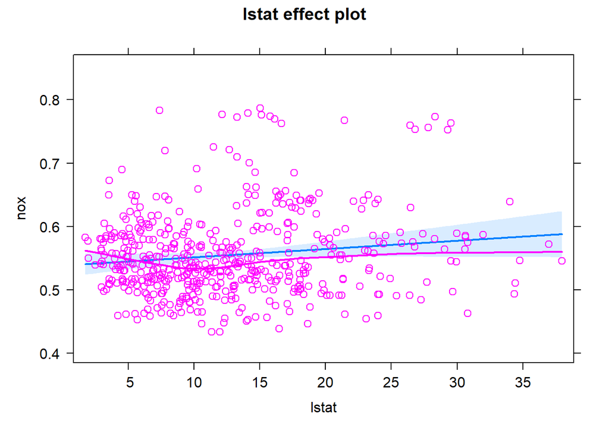

```r
plot(effect("lstat", mod = lin_mod, partial.residuals = TRUE))
```

### Linear fit

```r
lstat_lin <- train(nox ~ lstat, data = reg_data, method = "lm", trControl = train_control)
lstat_lin_RMSE <- lstat_lin$results$RMSE
```

### Poly Fit

```r
poly_mse <- rep(0, 8)

for (i in 1:8) {
    data <- reg_data
    data$polyfit <- poly(data$lstat, i)
    poly_lstat <- train(nox ~ polyfit, data = data,
        method = "lm", trControl = train_control)
    poly_mse[i] <- poly_lstat$results$RMSE
}

lstat_poly_RMSE <- min(poly_mse)

which.min(poly_mse)
```

```
## [1] 5
```

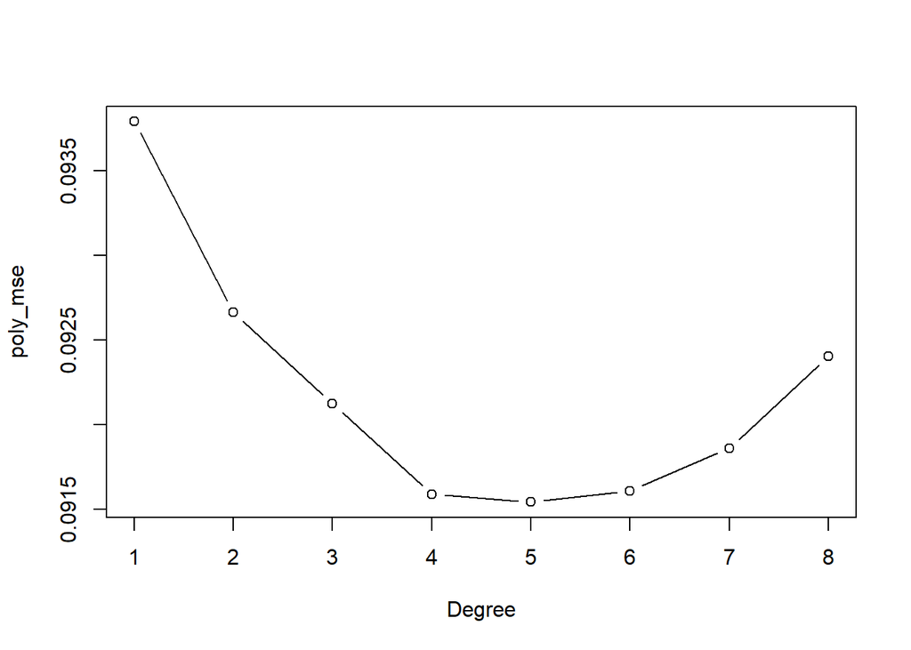

```r
plot(1:8, poly_mse, type = "b", xlab = "Degree")
```

### Basis Splines Fit

```r
bs_mse <- rep(0, 20)

for (i in 1:20) {
    data <- reg_data
    data$bspline <- bs(reg_data$lstat, df = i)
    bs_lstat <- train(nox ~ bspline, data = data,
        method = "lm", trControl = train_control)
    bs_mse[i] <- bs_lstat$results$RMSE
}
lstat_bs_RMSE <- min(bs_mse)

which.min(bs_mse)
```

```
## [1] 4
```

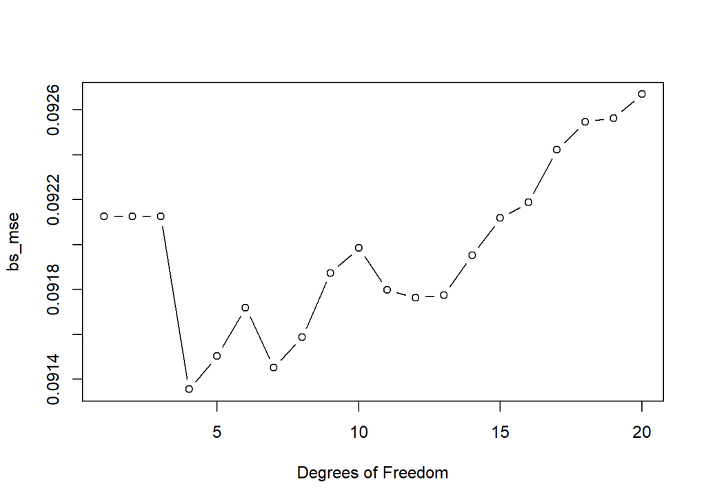

```r
plot(1:20, bs_mse, type = "b", xlab = "Degrees of Freedom")
```

### Natural Splines

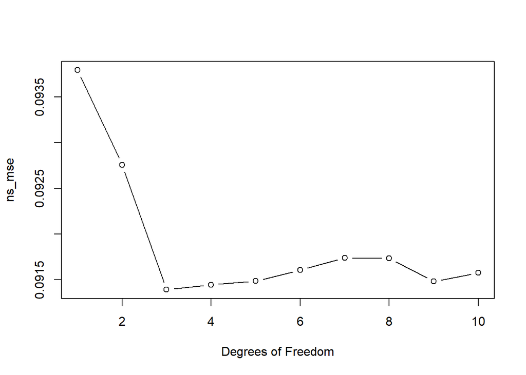

```r
ns_mse <- rep(0, 10)

for (i in 1:10) {
    data <- reg_data
    data$nspline <- ns(reg_data$lstat, df = i)
    lstat_ns <- train(nox ~ nspline, data = data,
        method = "lm", trControl = train_control)
    ns_mse[i] <- lstat_ns$results$RMSE
}

lstat_ns_RMSE <- min(ns_mse)

plot(1:10, ns_mse, type = "b", xlab = "Degrees of Freedom")
```

### Lstat Selection

```r
which.min(c(lstat_lin_RMSE, lstat_poly_RMSE, lstat_bs_RMSE, lstat_ns_RMSE))
```

```
## [1] 3
```

```r
lstat_lin_RMSE
```

```
## [1] 0.09379216
```

```r
min(poly_mse)
```

```
## [1] 0.09154488
```

```r
min(bs_mse)
```

```
## [1] 0.09135595
```

```r
min(ns_mse)
```

```
## [1] 0.09139166
```

```r
which.min(poly_mse)
```

```
## [1] 5
```

```r
which.min(bs_mse)
```

```
## [1] 4
```

```r
which.min(ns_mse)
```

```
## [1] 3
```

Again, the RMSE’s are all very similar, so we’ll stick with the simplest fit - `ns(lstat, df = 3)` in this case.

## medv

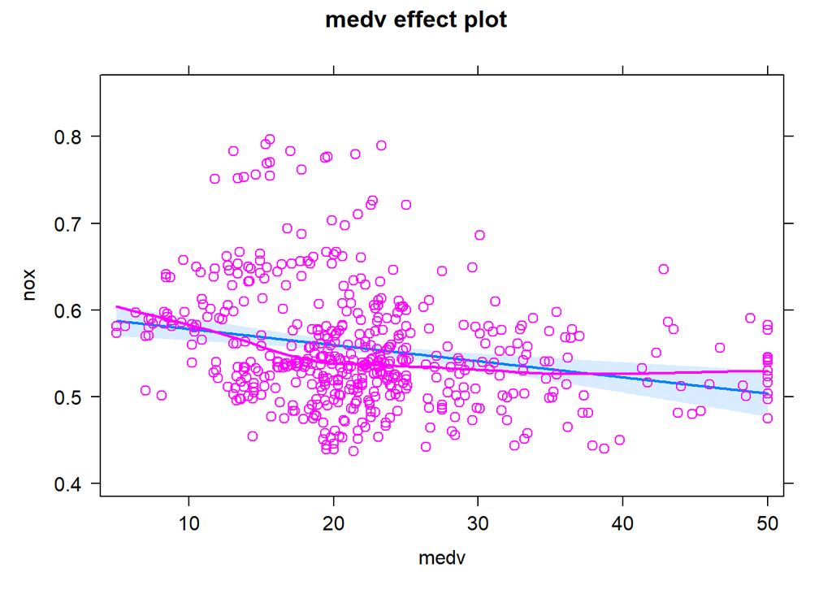

```r
plot(effect("medv", mod = lin_mod, partial.residuals = TRUE))
```

### Linear fit

```r
medv_lin <- train(nox ~ medv, data = reg_data, method = "lm", trControl = train_control)
medv_lin_RMSE <- medv_lin$results$RMSE
```

### Poly Fit

```r
poly_mse <- rep(0, 8)

for (i in 1:8) {
    data <- reg_data
    data$polyfit <- poly(data$medv, i)
    poly_medv <- train(nox ~ polyfit, data = data,
        method = "lm", trControl = train_control)
    poly_mse[i] <- poly_medv$results$RMSE
}

medv_poly_RMSE <- min(poly_mse)

which.min(poly_mse)
```

```
## [1] 8
```

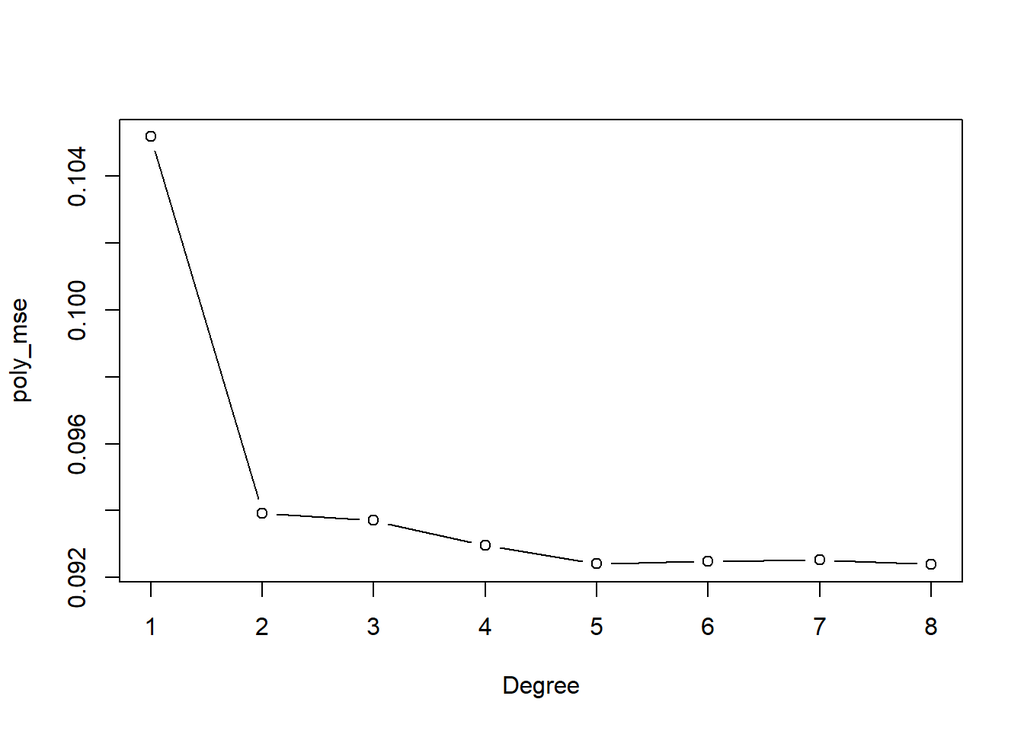

```r
plot(1:8, poly_mse, type = "b", xlab = "Degree")
```

### Basis Splines Fit

```r
bs_mse <- rep(0, 20)

for (i in 1:20) {
    data <- reg_data
    data$bspline <- bs(reg_data$medv, df = i)
    bs_medv <- train(nox ~ bspline, data = data,
        method = "lm", trControl = train_control)
    bs_mse[i] <- bs_medv$results$RMSE
}
medv_bs_RMSE <- min(bs_mse)

which.min(bs_mse)
```

```
## [1] 7
```

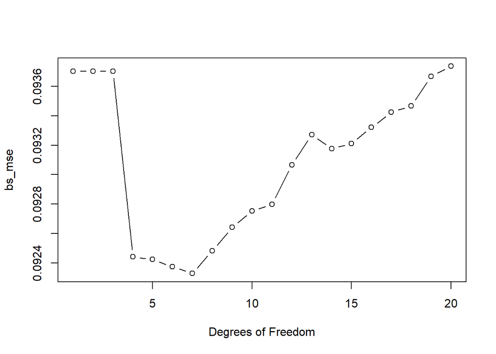

```r
plot(1:20, bs_mse, type = "b", xlab = "Degrees of Freedom")
```

### Natural Splines

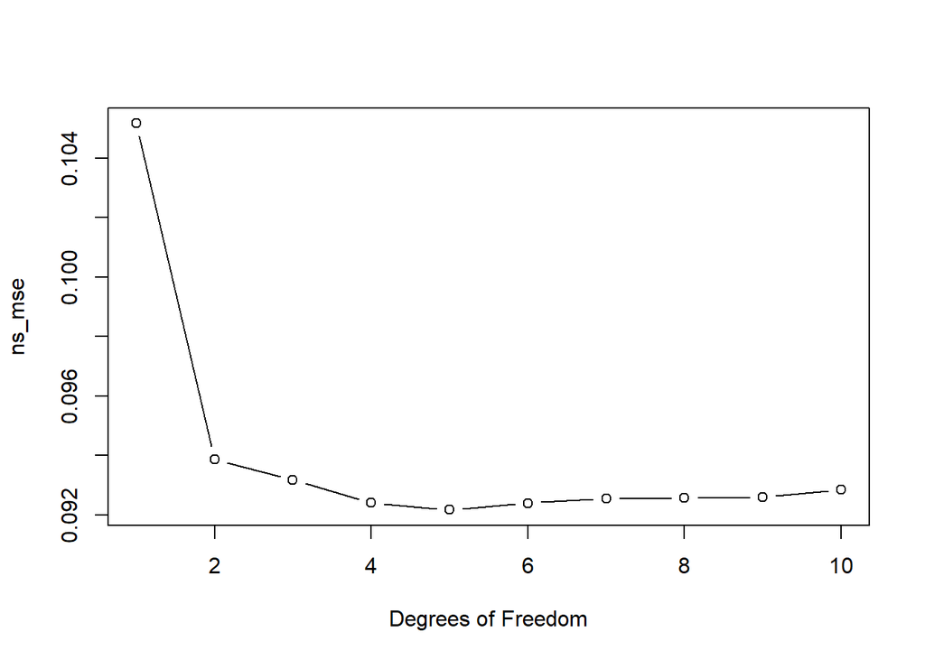

```r
ns_mse <- rep(0, 10)

for (i in 1:10) {
    data <- reg_data
    data$nspline <- ns(reg_data$medv, df = i)
    medv_ns <- train(nox ~ nspline, data = data,
        method = "lm", trControl = train_control)
    ns_mse[i] <- medv_ns$results$RMSE
}

medv_ns_RMSE <- min(ns_mse)

plot(1:10, ns_mse, type = "b", xlab = "Degrees of Freedom")
```

### medv Selection

```r
which.min(c(medv_lin_RMSE, medv_poly_RMSE, medv_bs_RMSE, medv_ns_RMSE))
```

```
## [1] 4
```

```r
lstat_lin_RMSE
```

```
## [1] 0.09379216
```

```r
min(poly_mse)
```

```
## [1] 0.09239106
```

```r
min(bs_mse)
```

```
## [1] 0.0923283
```

```r
min(ns_mse)
```

```
## [1] 0.09217618
```

```r
which.min(poly_mse)
```

```
## [1] 8
```

```r
which.min(bs_mse)
```

```
## [1] 7
```

```r
which.min(ns_mse)
```

```
## [1] 5
```

It appears as though `ns(medv, df = 5)` results in both the lowest RMSE and the simpliest model.

## Subset Selection

```r
# 0 Inputs
mod_0 <- lm(nox ~ 1, data = reg_data)

# 1 Input
age_fit <- lm(nox ~ ns(age, df = 2), data = reg_data)
dis_fit <- lm(nox ~ poly(dis, 2), data = reg_data)
lstat_fit <- lm(nox ~ ns(lstat, df = 3), data = reg_data)
medv_fit <- lm(nox ~ ns(medv, df = 5), data = reg_data)
which.min(c(deviance(age_fit), deviance(dis_fit), deviance(lstat_fit), deviance(medv_fit)))
```

```
## [1] 2
```

```r
# poly(dis, 2) is the winnder

# 2 Inputs

age_dis_fit <- lm(nox ~ ns(age, df = 2) + poly(dis, 2), data = reg_data)
age_lstat_fit <- lm(nox ~ ns(age, df = 2) + ns(lstat, df = 3), data = reg_data)
age_medv_fit <- lm(nox ~ ns(age, df = 2) + ns(medv, df = 5), data = reg_data)
dis_lstat_fit <- lm(nox ~ poly(dis, 2) + ns(lstat, df = 3), data = reg_data)
dis_medv_fit <- lm(nox ~ poly(dis, 2) + ns(medv, df = 5), data = reg_data)
lstat_medv_fit <- lm(nox ~ ns(lstat, df = 3) + ns(medv, df = 5), data = reg_data)
which.min(c(deviance(age_dis_fit), deviance(age_lstat_fit), deviance(age_medv_fit), deviance(dis_lstat_fit), deviance(dis_medv_fit), deviance(lstat_medv_fit)))
```

```
## [1] 5
```

```r
# poly(dis, 2) + ns(medv, df = 5) is the winner

# 3 Inputs

age_dis_lstat_fit <- lm(nox ~ ns(age, df = 2) + poly(dis, 2) + ns(lstat, df = 3), data = reg_data)
age_dis_medv_fit <- lm(nox ~ ns(age, df = 2) + poly(dis, 2) + ns(medv, df = 5), data = reg_data)
dis_lstat_medv_fit <- lm(nox ~ poly(dis, 2) + ns(lstat, df = 3) + ns(medv, df = 5), data = reg_data)
which.min(c(deviance(age_dis_lstat_fit), deviance(age_dis_medv_fit), deviance(dis_lstat_medv_fit)))
```

```
## [1] 2
```

```r
# ns(age, df = 2) + poly(dis, 2) + ns(medv, df = 5) is the winner

# 4 inputs

full_fit <- lm(nox ~ ns(age, df = 2) + poly(dis, 2) + ns(lstat, df = 3) + ns(medv, df = 5), data = reg_data)

# Cross Validation
reg_data$const <- rep(0, dim(reg_data)[1])

fit_1 <- train(nox ~ const, data = reg_data, method = "lm", trControl = train_control)
```

[output not shown]

[output cut: 1462 more lines]

[output not shown]

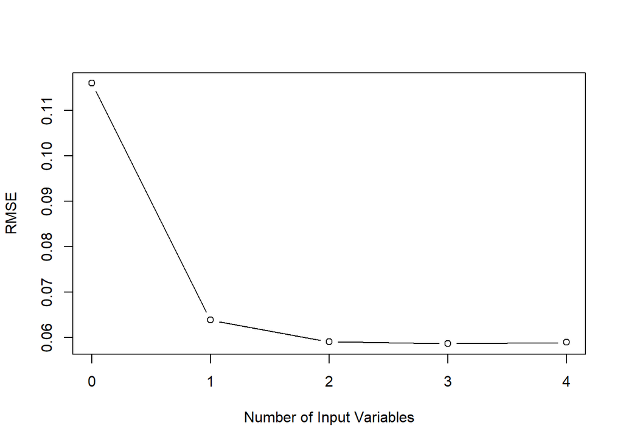

```r
fit_2 <- train(nox ~ poly(dis, 2), data = reg_data, method = "lm", trControl = train_control)
fit_3 <- train(nox ~ poly(dis, 2) + ns(medv, df = 5), data = reg_data, method = "lm", trControl = train_control)
fit_4 <- train(nox ~ ns(age, df = 2) + poly(dis, 2) + ns(medv, df = 5), data = reg_data, method = "lm", trControl = train_control)
fit_5 <- train(nox ~ ns(age, df = 2) + poly(dis, 2) + ns(lstat, df = 3) + ns(medv, df = 5), data = reg_data, method = "lm", trControl = train_control)

mod_comp <- data.frame(mse = c(fit_1$results$RMSE, fit_2$results$RMSE, fit_3$results$RMSE, fit_4$results$RMSE, fit_5$results$RMSE),
                      Inputs = c(0, 1, 2, 3, 4))

plot(mod_comp$Inputs, mod_comp$mse, type = "b", xlab = "Number of Input Variables", ylab = "RMSE")
```

The conclusion is that two inputs of `dis` and `medv` make the model better than each term individually, but adding a third input (`age`) or fourth input (`lstat`) makes no appreciable improvement. In this instance, we would likely only keep the first two inputs, to ensure a parsamonious model.